# Introduction

In this project we are going to analyze 'Brain tumor dataset', a T1 weighted MRI dataset from figshare,  
apply preprocessing functions and create image classification model based on Convolutional neural network that predicts brain tumor type.  
**Contents:**

1. **Data exploration**  
   1.1 - Image extraction  
   1.2 - Splitting Data  
   1.3 - Preview images  
   1.4 - Black/White balance  
   1.5 - Skull size  
   1.6 - Class weights  
   1.7 - Feature scaling
2. **Neural Network Model**  
   2.1 - Building a model  
   2.2 - Visualising results  
   2.3 - Testing the model
3. **Conclusion**

Highly reccomended to read the **data-description.txt** file to understand data organization.

# I Data exploration

#### 1.1 - Image extraction

The Dataset is in .mat format, so we extract the image values to regular image files.  
For this task we're going to use h2py and cv2 libraries and iterate through mat dataset.  
*We don't really need to do that, but I want to show the process as working with regular images.  
Technically we supposed to to assign labels to integer values because later on we'll use loss='sparse_categorical_crossentropy' which is prepared for said value type.

```python
import tensorflow as tf
import numpy as np
import os

# apply stable seed to avoid inconsistent results every time we test new setup
tf.config.experimental.enable_op_determinism()
tf.keras.utils.set_random_seed(0)
tf.random.set_seed(0)
np.random.seed(0)

# define paths for datasets
mat_path = 'D:\\data-science\\brain-tumor-data\\mat'
data_path = 'D:\\data-science\\brain-tumor-data\\images'
data_path_split = data_path + '_split'
matrices = os.listdir(mat_path)
```

```python
import matplotlib.pyplot as plt

# DON'T MIND THIS, it's dark theme for matplotlib
WHITE_MID = '#b5b5b5'
GREY_DARK = '#141414'

plt.rcParams['figure.facecolor'] = GREY_DARK
plt.rcParams['text.color'] = WHITE_MID
plt.rcParams['axes.facecolor'] = GREY_DARK
plt.rcParams['axes.edgecolor'] = WHITE_MID
plt.rcParams['axes.labelcolor'] = WHITE_MID
plt.rcParams['axes.titlecolor'] = WHITE_MID

plt.rcParams['grid.color'] = WHITE_MID
plt.rcParams['grid.linestyle'] = '--'
plt.rcParams['grid.linewidth'] = 0.5
plt.rcParams['axes.grid'] = True

plt.rcParams['axes.linewidth'] = 1
plt.rcParams['xtick.color'] = WHITE_MID
plt.rcParams['ytick.color'] = WHITE_MID
plt.rcParams['legend.edgecolor'] = WHITE_MID
plt.rcParams['legend.labelcolor'] = WHITE_MID
```

```python
from skimage import exposure
import cv2 as cv
import h5py

label_names = {1: 'meningioma',
               2: 'glioma',
               3: 'pituitary'}

# this iteration generates .png files in data_path directory
for i, mat in enumerate(matrices):
    break

    # reads the .mat files from mat data path
    with h5py.File(f"{mat_path}\\{mat}", 'r') as file:
        image = file['cjdata']['image']
        label = int(file['cjdata']['label'][0])

        # normalize values by maximum where [min, max] = [0, 1]
        image = np.array(image) / np.max(image)
        image *= 255

        # taking off 'near black' values to reduce background noise
        # image[image <= 0.05] = 0
        # image *= 255

        # apply contrast stretching
        # image = exposure.rescale_intensity(image)
        # image *= 255

        # increase exposure
        # image = exposure.equalize_hist(image)

        image = np.array(image).astype(np.uint8)

        # save the results to new data path
        cv.imwrite(os.path.join(data_path, label_names[label], f"{label_names[label]}_{i}.png"), image)
    # print(f"\r{int((i + 1) / 3064)} %", end='', flus=True)
print('Done!')
```

```
Done!
```

#### 1.2 - Splitting data

For this task we use *splitfolders* library. This makes us sure that data is correctly split without any leaks.  
**Ratio:**  
train: 70%  
val: 20%  
test: 10%

```python
import splitfolders

splitfolders.ratio(input=data_path, output=data_path_split, ratio=(.7, .2, .1), seed=0)
```

```
Copying files: 3064 files [00:02, 1177.17 files/s]
```

```python
train = tf.keras.utils.image_dataset_from_directory(os.path.join(data_path_split, 'train'), batch_size=8, color_mode='grayscale', image_size=(256, 256))
test = tf.keras.utils.image_dataset_from_directory(os.path.join(data_path_split, 'test'), batch_size=8, color_mode='grayscale', image_size=(256, 256))
val = tf.keras.utils.image_dataset_from_directory(os.path.join(data_path_split, 'val'), batch_size=8, color_mode='grayscale', image_size=(256, 256))

data_iterator = test.as_numpy_iterator()
batch = data_iterator.next()

labels = test.class_names
labels
```

```
Found 2144 files belonging to 3 classes.
Found 308 files belonging to 3 classes.
Found 612 files belonging to 3 classes.
```

```
['glioma', 'meningioma', 'pituitary']
```

To ensure that there are no leaks that might overfit our model learning process or lead to false accuracy results during testing  
I applied simple iterations that takes every image from one split and compares it with each image from another split.

```python
# take all images per dataset split into one array for better iteration
train_images = np.concatenate([img.numpy() for img, label in train], axis=0)
val_images = np.concatenate([img.numpy() for img, label in val], axis=0)
test_images = np.concatenate([img.numpy() for img, label in test], axis=0)

count = 0
for train_img in train_images:
    # break
    if any(np.array_equal(train_img, val_img) for val_img in val_images):
        count += 1
print(f"There are {count} data leaks between train and val splits.")

count = 0
for train_img in train_images:
    # break
    if any(np.array_equal(train_img, test_img) for test_img in test_images):
        count += 1
print(f"There are {count} data leaks between train and test splits.")

count = 0
for val_img in val_images:
    # break
    if any(np.array_equal(val_img, test_img) for test_img in test_images):
        count += 1
print(f"There are {count} data leaks between val and test splits.")
```

```
There are 0 data leaks between train and val splits.
There are 0 data leaks between train and test splits.
There are 0 data leaks between val and test splits.
```

#### 1.3 - Preview the images

Data iterator allows us to move through data and preview it more swiftly.

```
   batches: 8
     width: 256
    height: 256
  channels: 1
```

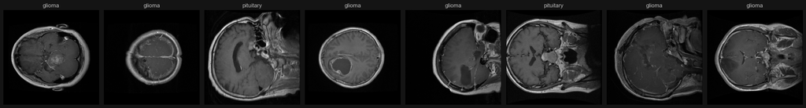

```python
import seaborn as sb

fig, axes = plt.subplots(nrows=1, ncols=8, figsize=(24, 6))
for i, img in enumerate(batch[0][:8]):
    class_name = labels[batch[1][i]]
    axes[i].imshow(img, cmap='gray')
    axes[i].set_title(class_name)
    axes[i].set_axis_off()

for key, value in zip(['batches', 'width', 'height', 'channels'], batch[0].shape):
    print(f"{key:>10}: {value}")

plt.tight_layout()
plt.show()
```

#### 1.4 - Black/white balance

Every point on the plot is a single image, we can note that most of images hang around 45.

```
          Mean: 45.710609436035156
 Harmonic mean: 44.06211853027344
```

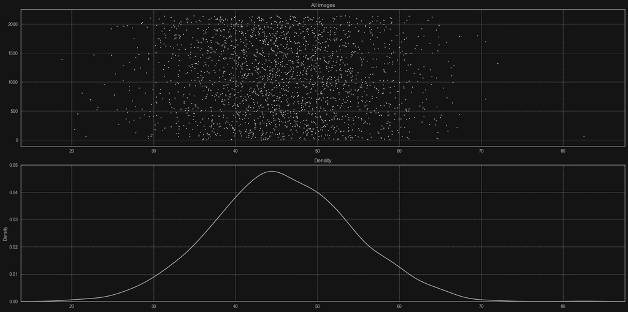

```python
from scipy.stats.mstats import hmean

# skipping value 0 because it's background and it will lower our mean
all_means = [x[x != 0].mean() for x in train_images]

print(f'{'Mean':>14}: {np.mean(all_means)}\n'
      f'{'Harmonic mean':>14}: {hmean(all_means)}')

fig, axes = plt.subplots(nrows=2, ncols=1, figsize=(20, 10))
sb.scatterplot(y=[x for x in range(len(all_means))], x=all_means, color=WHITE_MID, s=20, ax=axes[0], marker='.', linewidth=0)
sb.kdeplot(x=all_means, ax=axes[1], color=WHITE_MID)

padding = (min(all_means) - 5, max(all_means) + 5)
axes[0].set_xlim(padding)
axes[0].set_title('All images')
axes[1].set_xlim(padding)
axes[1].set_title('Density')
plt.tight_layout()
```

#### 1.5 Skull size

By calculating amount of black pixels inside image we can extract images with specific skull/head size.  
*threshold* is max value that we consider/define as black background. The more the noisy our background is the higher the threshold we apply.  
In summary this plot returns images where background fills specified % (see percentage variable) of area.

```
There are 18 image/s with background filling more than 75.0%
```

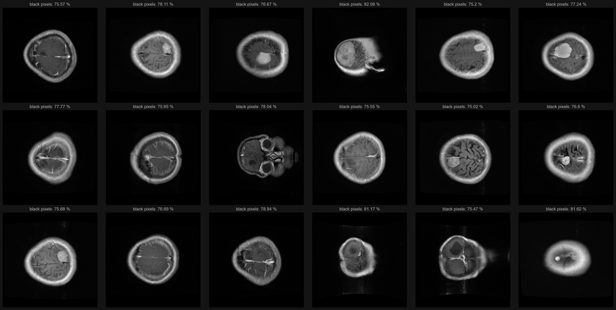

```python
threshold = 10
percentage = 0.75

all_images = np.concatenate([train_images, val_images, test_images], axis=0)
dataset_black_pixels =[]

fig, axes = plt.subplots(nrows=3, ncols=6, figsize=(24, 12))
axes = axes.flatten()

small_skull = 0
i = 0
for img in all_images:
    n_black_pixels = np.sum(img <= threshold)
    percentage_black_pixels = n_black_pixels / (256*256)
    dataset_black_pixels.append(percentage_black_pixels)

    if percentage_black_pixels > percentage:
        if i < 18:
            small_skull += 1
            axes[i].set_title(f"black pixels: {round(percentage_black_pixels * 100, 2)} %")
            axes[i].set_axis_off()
            axes[i].imshow(img, cmap='gray')
            i += 1

print(f"There are {small_skull} image/s with background filling more than {percentage * 100}%")
plt.tight_layout()
```

I suppose these are newborns but last image looks like top of the skull.  
Note that the photos are from a single dataset,  
so it is very likely that the photos have not been previously scaled, and the brains do not appear to be developed.  
This allow us to categorize images based on skull size.

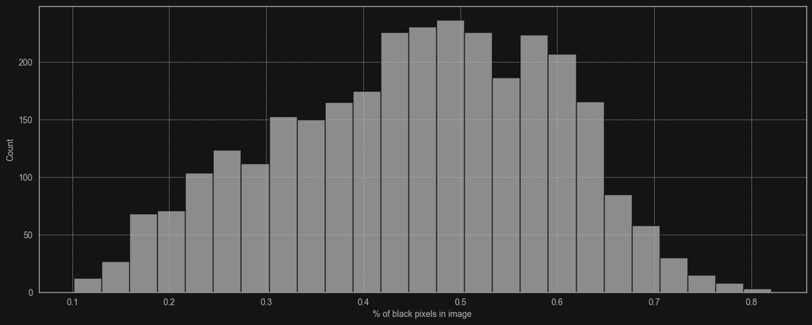

```python
plt.figure(figsize=(16, 6))

sb.histplot(data=dataset_black_pixels, color=WHITE_MID, linewidth=1, edgecolor=GREY_DARK)
plt.xlabel('% of black pixels in image')
plt.show()
```

#### 1.6 - Class weights

```
Class        Count
glioma     : 1426
meningioma : 708
pituitary  : 930
```

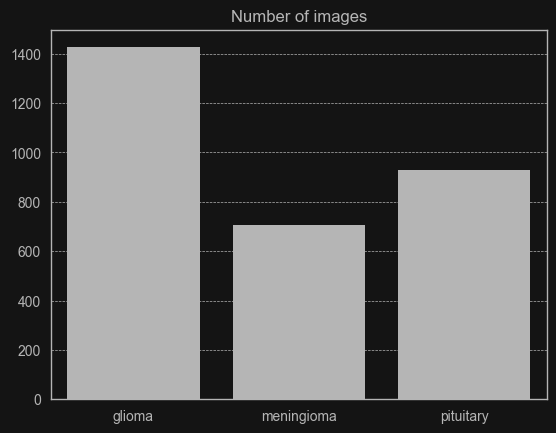

```python
files_per_label = lambda folder: os.listdir(os.path.join(data_path, folder))

# generate dictionary with lengths for each label
labels_len = {label: len(files_per_label(label)) for i, label in enumerate(labels)}

sb.barplot(data=labels_len, x=labels_len.keys(), y=labels_len.values(), color=WHITE_MID, linewidth=0)

print(f"{'Class':<10}   Count")
for label, count in labels_len.items():
    print(f"{label:<10} : {count}")

plt.title('Number of images')
plt.show()
```

**To handle class imbalance, we can calculate weights with given formula:**  
$w_c = \frac{N}{N_c * C}$  
where:  
$ w_c $ = class weight  
$ N $ = number of samples in dataset  
$ N_c $ = number of samples in class  
$ C $ = number of unique classes in dataset

```python
class_weights = dict()

for i, count in enumerate(labels_len.values()):
    class_weights[i] = sum(labels_len.values()) / (len(labels) * count)

print(f"{'Class':<10}   Weight")
for i, weight in class_weights.items():
    print(f"{labels[i]:<10} : {weight}")
```

```
Class        Weight
glioma     : 0.7162225338943432
meningioma : 1.4425612052730696
pituitary  : 1.0982078853046595
```

#### 1.7 - Feature scaling

Usually when we work with Images, the max value is 255 so we're going to transform our values from [min, max] = [0, 255] to [0, 1].

```python
print(batch[0].min(), batch[0].max(), sep='\n')
```

```
0.0
250.75
```

```python
train = train.map(lambda x, y: (x/255, y))
test = test.map(lambda x, y: (x/255, y))
val = val.map(lambda x, y: (x/255, y))

iterator = test.as_numpy_iterator()
batch = iterator.next()

min_value = iterator.next()[0].min()
max_value = iterator.next()[0].max()

print(min_value, max_value, sep='\n')
```

```
0.0
0.98137254
```

# II Neural Network Model

#### 2.1 - Building a model

In short our model base on convolutional layers, where each layer contain filter that convolve with input matrix (image) resulting filtered output.  
As input shape we apply values that corresponds to:

- width = 256
- height = 256
- channel = 1 (grayscale).

*ReLU* activation function cleans our output from all unnecessary negative values, replacing them with zeros.  
*Dropout* layers drops random neurons each time convolution layer is being applied, reducing chance to overfit.  
Since our dataset contain 3 classes I applied *softmax* activation to the last step.

```python
from tensorflow.keras.models import Sequential
from tensorflow.keras.layers import Conv2D, MaxPooling2D, Dense, Flatten, Dropout, Input, ReLU
from tensorflow.keras.regularizers import l1, l2, l1_l2
from tensorflow.keras.optimizers import Adam, SGD
from tensorflow.keras.callbacks import ModelCheckpoint, EarlyStopping
```

```python
def create_model(num_filters=16, kernel_size=3, learning_rate=0, regulate=0, slope=0):

    model = Sequential()

    model.add(Input(shape=(256, 256, 1)))

    model.add(Conv2D(num_filters, (kernel_size, kernel_size), 1, activation='relu'))
    model.add(Dropout(0.3))
    model.add(MaxPooling2D())

    model.add(Conv2D(num_filters * 2, (kernel_size, kernel_size), 1, activation='relu'))
    model.add(Dropout(0.3))
    model.add(MaxPooling2D())

    model.add(Conv2D(num_filters, (kernel_size, kernel_size), 1, activation='relu'))
    model.add(Dropout(0.3))
    model.add(MaxPooling2D())

    model.add(Flatten())
    model.add(Dense(256, activation='relu'))
    model.add(Dropout(0.5))
    model.add(Dense(3, activation='softmax'))

    model.compile(optimizer=Adam(learning_rate=learning_rate), loss='sparse_categorical_crossentropy', metrics=['sparse_categorical_accuracy'])

    return model
```

```python
model = create_model(learning_rate=0.0005)
model.summary()
```

```
Model: "sequential_10"
```

```
┏━━━━━━━━━━━━━━━━━━━━━━━━━━━━━━━━━┳━━━━━━━━━━━━━━━━━━━━━━━━┳━━━━━━━━━━━━━━━┓
┃ Layer (type)                    ┃ Output Shape           ┃       Param # ┃
┡━━━━━━━━━━━━━━━━━━━━━━━━━━━━━━━━━╇━━━━━━━━━━━━━━━━━━━━━━━━╇━━━━━━━━━━━━━━━┩
│ conv2d_30 (Conv2D)              │ (None, 254, 254, 16)   │           160 │
├─────────────────────────────────┼────────────────────────┼───────────────┤
│ dropout_40 (Dropout)            │ (None, 254, 254, 16)   │             0 │
├─────────────────────────────────┼────────────────────────┼───────────────┤
│ max_pooling2d_30 (MaxPooling2D) │ (None, 127, 127, 16)   │             0 │
├─────────────────────────────────┼────────────────────────┼───────────────┤
│ conv2d_31 (Conv2D)              │ (None, 125, 125, 32)   │         4,640 │
├─────────────────────────────────┼────────────────────────┼───────────────┤
│ dropout_41 (Dropout)            │ (None, 125, 125, 32)   │             0 │
├─────────────────────────────────┼────────────────────────┼───────────────┤
│ max_pooling2d_31 (MaxPooling2D) │ (None, 62, 62, 32)     │             0 │
├─────────────────────────────────┼────────────────────────┼───────────────┤
│ conv2d_32 (Conv2D)              │ (None, 60, 60, 16)     │         4,624 │
├─────────────────────────────────┼────────────────────────┼───────────────┤
│ dropout_42 (Dropout)            │ (None, 60, 60, 16)     │             0 │
├─────────────────────────────────┼────────────────────────┼───────────────┤
│ max_pooling2d_32 (MaxPooling2D) │ (None, 30, 30, 16)     │             0 │
├─────────────────────────────────┼────────────────────────┼───────────────┤
│ flatten_10 (Flatten)            │ (None, 14400)          │             0 │
├─────────────────────────────────┼────────────────────────┼───────────────┤
│ dense_20 (Dense)                │ (None, 256)            │     3,686,656 │
├─────────────────────────────────┼────────────────────────┼───────────────┤
│ dropout_43 (Dropout)            │ (None, 256)            │             0 │
├─────────────────────────────────┼────────────────────────┼───────────────┤
│ dense_21 (Dense)                │ (None, 3)              │           771 │
└─────────────────────────────────┴────────────────────────┴───────────────┘
```

```
 Total params: 3,696,851 (14.10 MB)
```

```
 Trainable params: 3,696,851 (14.10 MB)
```

```
 Non-trainable params: 0 (0.00 B)
```

```python
n_epochs = 20

early_stopping = EarlyStopping(
    monitor='val_loss',
    restore_best_weights=True,
    baseline=None,
    min_delta=0,
    patience=n_epochs,
    verbose=0,
)
```

```python
hist = model.fit(train, validation_data=val, epochs=n_epochs, class_weight=class_weights, verbose=2, callbacks=[early_stopping])
```

```
268/268 - 27s - 102ms/step - loss: 0.6682 - sparse_categorical_accuracy: 0.6637 - val_loss: 0.6406 - val_sparse_categorical_accuracy: 0.7337
268/268 - 25s - 92ms/step - loss: 0.4556 - sparse_categorical_accuracy: 0.8018 - val_loss: 0.5746 - val_sparse_categorical_accuracy: 0.7304
268/268 - 25s - 92ms/step - loss: 0.3292 - sparse_categorical_accuracy: 0.8554 - val_loss: 0.4751 - val_sparse_categorical_accuracy: 0.7712
268/268 - 25s - 91ms/step - loss: 0.2172 - sparse_categorical_accuracy: 0.9086 - val_loss: 0.4267 - val_sparse_categorical_accuracy: 0.7941
268/268 - 25s - 93ms/step - loss: 0.1726 - sparse_categorical_accuracy: 0.9296 - val_loss: 0.3975 - val_sparse_categorical_accuracy: 0.8072
268/268 - 28s - 106ms/step - loss: 0.1231 - sparse_categorical_accuracy: 0.9515 - val_loss: 0.3416 - val_sparse_categorical_accuracy: 0.8366
268/268 - 25s - 93ms/step - loss: 0.0915 - sparse_categorical_accuracy: 0.9669 - val_loss: 0.2825 - val_sparse_categorical_accuracy: 0.8840
268/268 - 26s - 97ms/step - loss: 0.0722 - sparse_categorical_accuracy: 0.9739 - val_loss: 0.2430 - val_sparse_categorical_accuracy: 0.9052
268/268 - 26s - 97ms/step - loss: 0.0626 - sparse_categorical_accuracy: 0.9757 - val_loss: 0.2140 - val_sparse_categorical_accuracy: 0.9314
268/268 - 26s - 96ms/step - loss: 0.0552 - sparse_categorical_accuracy: 0.9785 - val_loss: 0.2508 - val_sparse_categorical_accuracy: 0.8856
268/268 - 26s - 96ms/step - loss: 0.0346 - sparse_categorical_accuracy: 0.9855 - val_loss: 0.2395 - val_sparse_categorical_accuracy: 0.9085
268/268 - 26s - 96ms/step - loss: 0.0331 - sparse_categorical_accuracy: 0.9879 - val_loss: 0.2297 - val_sparse_categorical_accuracy: 0.9085
268/268 - 26s - 97ms/step - loss: 0.0431 - sparse_categorical_accuracy: 0.9832 - val_loss: 0.2443 - val_sparse_categorical_accuracy: 0.8938
268/268 - 26s - 95ms/step - loss: 0.0260 - sparse_categorical_accuracy: 0.9935 - val_loss: 0.2317 - val_sparse_categorical_accuracy: 0.9069
268/268 - 25s - 93ms/step - loss: 0.0268 - sparse_categorical_accuracy: 0.9930 - val_loss: 0.2007 - val_sparse_categorical_accuracy: 0.9232
268/268 - 27s - 100ms/step - loss: 0.0278 - sparse_categorical_accuracy: 0.9902 - val_loss: 0.1887 - val_sparse_categorical_accuracy: 0.9281
268/268 - 28s - 104ms/step - loss: 0.0264 - sparse_categorical_accuracy: 0.9902 - val_loss: 0.1946 - val_sparse_categorical_accuracy: 0.9232
268/268 - 27s - 101ms/step - loss: 0.0336 - sparse_categorical_accuracy: 0.9874 - val_loss: 0.1916 - val_sparse_categorical_accuracy: 0.9444
268/268 - 26s - 97ms/step - loss: 0.0174 - sparse_categorical_accuracy: 0.9944 - val_loss: 0.2049 - val_sparse_categorical_accuracy: 0.9232
268/268 - 26s - 97ms/step - loss: 0.0175 - sparse_categorical_accuracy: 0.9921 - val_loss: 0.1831 - val_sparse_categorical_accuracy: 0.9412
```

#### 2.2 - Visualising results

```
      val loss: 0.1830584704875946
  val accuracy: 0.9411764740943909
```

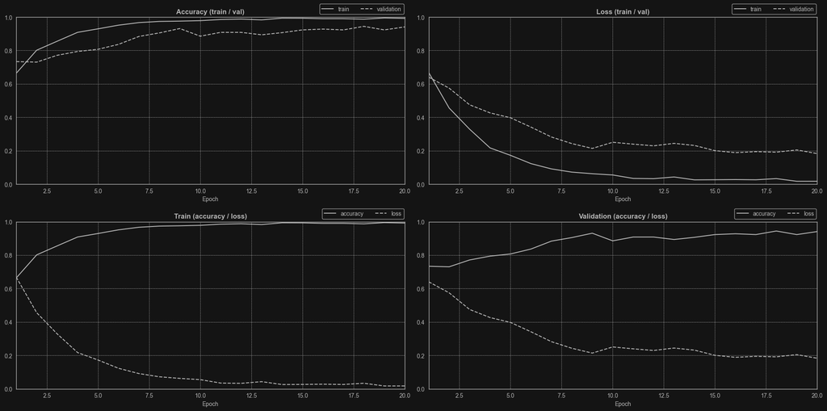

```python
acc_labels = list(hist.history.keys())

fig, axes = plt.subplots(nrows=2, ncols=2, figsize=(20, 10))
axes = axes.flatten()

sb.lineplot(data=hist.history, y='sparse_categorical_accuracy', x=[x for x in range(1, n_epochs+1, 1)], label='train', ax=axes[0], color=WHITE_MID)
sb.lineplot(data=hist.history, y='val_sparse_categorical_accuracy', x=[x for x in range(1, n_epochs+1, 1)], label='validation', ax=axes[0], linestyle='--', color=WHITE_MID)

sb.lineplot(data=hist.history, y='loss', x=[x for x in range(1, n_epochs+1, 1)], label='train', ax=axes[1], color=WHITE_MID)
sb.lineplot(data=hist.history, y='val_loss', x=[x for x in range(1, n_epochs+1, 1)], label='validation', ax=axes[1], linestyle='--', color=WHITE_MID)

sb.lineplot(data=hist.history, y='sparse_categorical_accuracy', x=[x for x in range(1, n_epochs+1, 1)], label='accuracy', ax=axes[2], color=WHITE_MID)
sb.lineplot(data=hist.history, y='loss', x=[x for x in range(1, n_epochs+1, 1)], label='loss', ax=axes[2], linestyle='--', color=WHITE_MID)

sb.lineplot(data=hist.history, y='val_sparse_categorical_accuracy', x=[x for x in range(1, n_epochs+1, 1)], label='accuracy', ax=axes[3], color=WHITE_MID)
sb.lineplot(data=hist.history, y='val_loss', x=[x for x in range(1, n_epochs+1, 1)], label='loss', ax=axes[3], linestyle='--', color=WHITE_MID)

for i in range(4):
    axes[i].legend(loc='lower right', bbox_to_anchor=(1.005, 1), ncol=2)
    axes[i].set_xlabel('Epoch')
    axes[i].set_ylim([0, 1])
    axes[i].set_xlim([1, n_epochs])
    axes[i].set_ylabel('')

axes[0].set_title('Accuracy (train / val)', weight='bold')
axes[1].set_title('Loss (train / val)', weight='bold')
axes[2].set_title('Train (accuracy / loss)', weight='bold')
axes[3].set_title('Validation (accuracy / loss)', weight='bold')

final_metrics = model.evaluate(val, verbose=0)
for key, value in zip(['val loss', 'val accuracy'], final_metrics):
    print(f"{key:>14}: {value}")

plt.tight_layout()
```

#### 2.3 - Testing the model

Both Training and Validation curves looks very promising, however we have to test our model for final results.

```python
y_true = []
y_pred = []

for batch_images, batch_labels in test:
    y_true_batch = batch_labels
    y_pred_batch = np.argmax(model.predict(batch_images, verbose=0), axis=1)

    y_true.extend(y_true_batch)
    y_pred.extend(y_pred_batch)

y_true = np.array(y_true)
y_pred = np.array(y_pred)
```

```
              precision    recall  f1-score   support

      glioma       0.97      0.98      0.97       143
  meningioma       0.95      0.86      0.91        72
   pituitary       0.94      0.99      0.96        93

    accuracy                           0.95       308
   macro avg       0.95      0.94      0.95       308
weighted avg       0.95      0.95      0.95       308
```

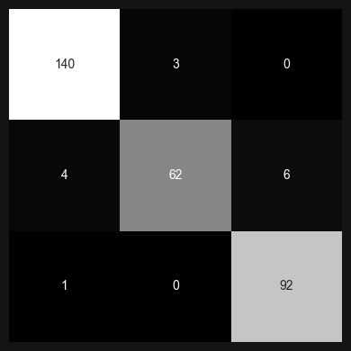

```python
from sklearn.metrics import classification_report, confusion_matrix

report = classification_report(y_true, y_pred, target_names=labels)
print(report)

cm = confusion_matrix(y_true=y_true, y_pred=y_pred)
fig = plt.figure(figsize=(4, 4))
fig = sb.heatmap(cm, annot=True, fmt='d', cbar=False, cmap='Greys_r', linewidths=0)
plt.xlabel('Predicted')
plt.ylabel('True')
plt.axis('off')
plt.tight_layout()
```

# III Conclusion

We ended up with decent F1 score of 95%. Despite this fact, model still have small problem with classifying *meningioma* class, propably because of it's size.  
Note that the dataset itself is very good quality, it's balanced in terms of specific factors like: resolution, color range, object placement.

#### Significant improvement noticed after:

- Tweaking learning rate of the Adam optimizer
- Weighting classes
- Adding dropout layers for each convolution layer  
  instead of holding one dropout layer before output densing layers.

#### Ideas to improve:

- Preprocessing images with kmeans color clustering, didn't returned better results.
- Removing small images (head size),  
  this meant to remove images where the number of black pixels exceeded a certain %.

#### Thanks for reading, I hope you enjoyed the analysis :]

*Gracjan Pawłowski, 2024*